# Two Variables: Linear Regression

Author

Orville D. Hombrebueno

Published

December 2, 2024

# The Data

```r
# install packages: install.packages("package")
# load packages
library(tidyverse)
library(knitr)
library(gtsummary)
library(ggstatsplot)
library(downlit)
library(broom)
library(car)
library(moderndive)
library(ggpubr)

# load data
data(mtcars)
```

## Motor Trend Car Road Tests

The data was extracted from the 1974 Motor Trend US magazine, and comprises fuel consumption and 10 aspects of automobile design and performance for 32 automobiles (1973–74 models).

A data frame with 32 observations on 11 (numeric) variables.

- `mpg` Miles/(US) gallon
- `cyl` Number of cylinders
- `disp` Displacement (cu.in.)
- `hp` Gross horsepower
- `drat` Rear axle ratio
- `wt` Weight (1000 lbs)
- `qsec` 1/4 mile time
- `vs` Engine (0 = V-shaped, 1 = straight)
- `am` Transmission (0 = automatic, 1 = manual)
- `gear` Number of forward gears
- `carb` Number of carburetors

The first 6 rows of the data set is shown in Table 1

```r
mtcars |> # call the data
  head() |> # get the first six rows of the data
  kable() # create a table
```

Table 1: The first 6 observations of the data set.

|  | mpg | cyl | disp | hp | drat | wt | qsec | vs | am | gear | carb |
| --- | --- | --- | --- | --- | --- | --- | --- | --- | --- | --- | --- |
| Mazda RX4 | 21.0 | 6 | 160 | 110 | 3.90 | 2.620 | 16.46 | 0 | 1 | 4 | 4 |
| Mazda RX4 Wag | 21.0 | 6 | 160 | 110 | 3.90 | 2.875 | 17.02 | 0 | 1 | 4 | 4 |
| Datsun 710 | 22.8 | 4 | 108 | 93 | 3.85 | 2.320 | 18.61 | 1 | 1 | 4 | 1 |
| Hornet 4 Drive | 21.4 | 6 | 258 | 110 | 3.08 | 3.215 | 19.44 | 1 | 0 | 3 | 1 |
| Hornet Sportabout | 18.7 | 8 | 360 | 175 | 3.15 | 3.440 | 17.02 | 0 | 0 | 3 | 2 |
| Valiant | 18.1 | 6 | 225 | 105 | 2.76 | 3.460 | 20.22 | 1 | 0 | 3 | 1 |

## Descriptive Statistics

The mean, standard deviation, minimum, and maximum of `mpg` and `wt` is shown in Table 2. There are a total of 32 observations.

```r
mtcars |> # call the data
  tbl_summary( # create a table
    include = c(mpg, wt), # select variables
    statistic = all_continuous() ~ "{mean} ± {sd} ({min} - {max})", # descriptive statistics
    digits = all_continuous() ~ 2 # no. of digits (rounding)
  )
```

Table 2: Summary statistics.

| **Characteristic** | **N = 32**<sup>1</sup> |
| --- | --- |
| mpg | 20.09 ± 6.03 (10.40 - 33.90) |
| wt | 3.22 ± 0.98 (1.51 - 5.42) |

<sup>1</sup> Mean ± SD (Min - Max)

# Linear Regression

A linear regression model was used to approximate the relationship between miles/(US) gallon and Weight (1000 lbs). The response variable is `mpg` and the explanatory variable is `wt`. The model summary is shown in Table 3.

```r
model <- lm(mpg ~ wt, data = mtcars)

get_regression_table(model) |>
  kable()
```

Table 3: Summary of least squares fit for the `mpg` and `wt`.

| term | estimate | std_error | statistic | p_value | lower_ci | upper_ci |
| --- | --- | --- | --- | --- | --- | --- |
| intercept | 37.285 | 1.878 | 19.858 | 0 | 33.450 | 41.120 |
| wt | -5.344 | 0.559 | -9.559 | 0 | -6.486 | -4.203 |

With the *p*-values less than 5%, there is strong evidence that the estimates are significantly different from 0. Weight (1000lb) significantly predicts miles/(US) gallon. For each additional weight (1000lb), the model predicts a decrease of 5.344 miles/(US) gallon. Figure 1 shows the plot of `mpg` vs `wt` and the regression line with 95% confidence interval. It also shows the linear model and the coefficient of determination, $R^2$. About 75% of the variability in miles/(US) gallon is explained by weight (1000lb) in the model. This also suggests a strong negative linear association between the variables.

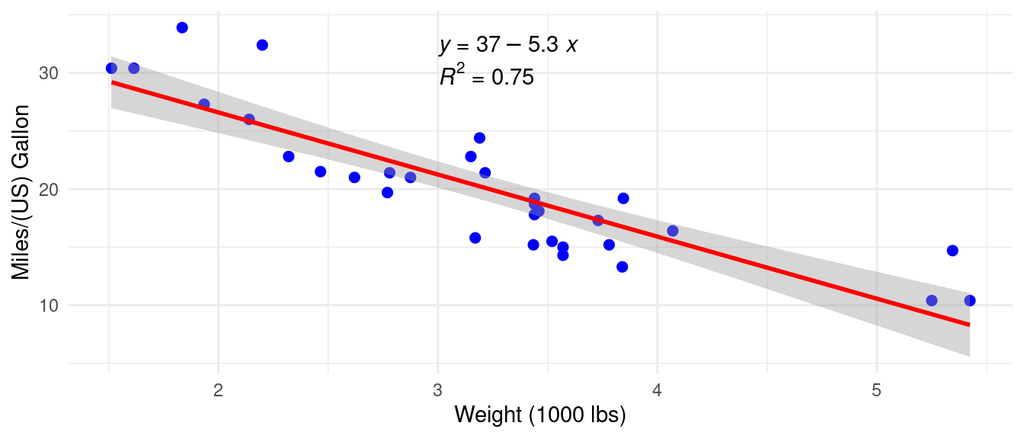

Figure 1: Weight and Miles/(US) Gallon

```r
ggplot(mtcars, aes(x = wt, y = mpg)) +
  geom_point(color = "blue", size = 2) +  # Add scatter points
  geom_smooth(method = "lm", color = "red", se = TRUE) +
  stat_regline_equation(aes(label = after_stat(eq.label)), label.x = 3) + # Regression equation
  stat_cor(aes(label = after_stat(rr.label)), label.x = 3, label.y = 30) + # R²
  labs(
    x = "Weight (1000 lbs)",
    y = "Miles/(US) Gallon"
  ) +
  theme_minimal()
```